# FPP Chapter 7: Exponential Smoothing

Timo Meiendresch

28/05/2019

```r
# libraries
library("fpp2")
```

# Introduction

Basics:

- Weighted averages of past observations
- weights decaying exponentially as the observations get older
- Hence, more recent observation gets higher weight

## Simple exponential smoothing

The simplest form is called **simple exponential smoothing** (SES).

- Suitable for data with no clear trend and no seasonal pattern.

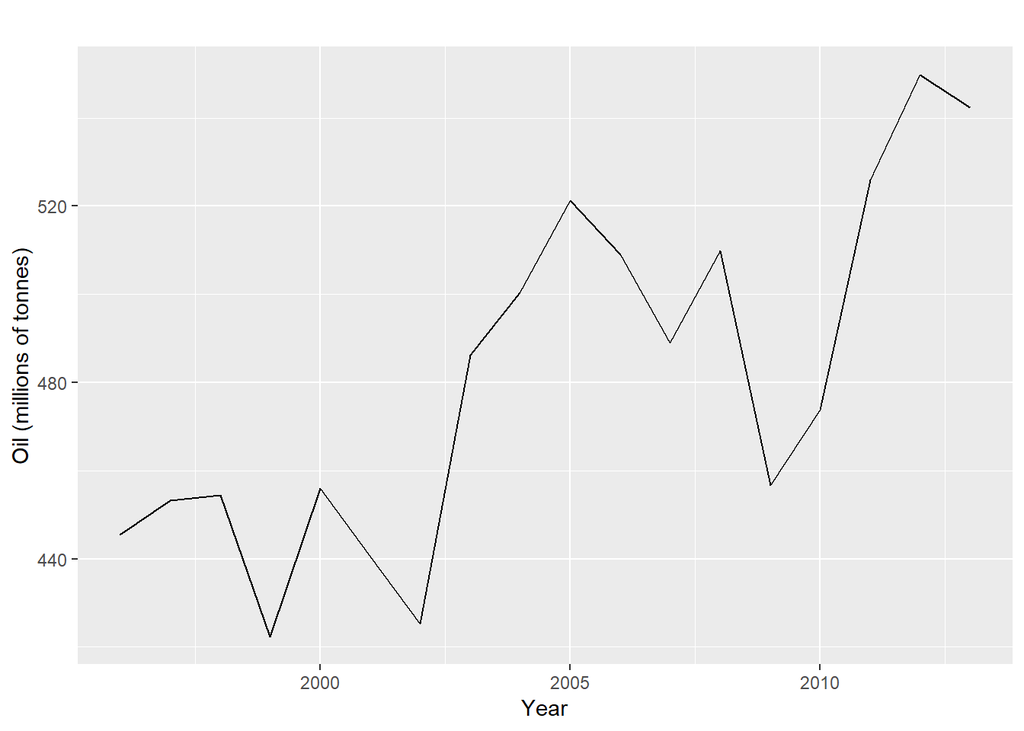

```r
oil <- window(oil, start=1996)
autoplot(oil) +
  ylab("Oil (millions of tonnes)") +
  xlab("Year")
```

Recall that the naive method simply took the last observation. Hence, the weight of the last observation was 1. On the other hand, averaging placed equal weight on all observations.

In simple exponential smoothing forecasts are calculated using weighted averages, where the weights decrease exponentially.

$$\hat{y}_{T+1|T} = \alpha \, y_T + \alpha\,(1-\alpha)y_{T-1} + \alpha\,(1-\alpha)^2 y_{T-2} + \,...$$

where $0 \leq \alpha \leq 1$ is the smoothing parameter.

#### Weighted average form

Forecast at time $T+1$ is equal to a weighted average between the most recent observation $y_T$ and the previous forecast $\hat{y}_{T|T-1}$:

$$\hat{y}_{T+1|t} = \alpha y_T + (1-\alpha) \hat{y}_{T|T-1}$$

Iterative substituion leads to

$$\hat{y}_{T+1|T} = \sum_{j=0}^{T-1} \alpha(1-\alpha)^j y_{T-j} + (1-\alpha)^T \ell_0$$
The last term becomes tiny for large T. So, the weighted average form leads to the same forecast equation stated at the beginning.

#### Component form

State equations in component form. For now, in simple exponential smoothing, the only component included is the level $\ell_t$. Later, a trend $b_t$ and a seasonal component $s_t$ will be added.

Component form of SES:

$$\begin{align*}
\text{Forecast equation} && \hat{y}_{t+h|t} & = \ell_{t}\\
\text{Smoothing equation} && \ell_{t} & = \alpha y_{t} + (1 - \alpha)\ell_{t-1},
\end{align*}$$

where $l_t$ is the level (smoothed value) of the series at time t. Setting $h=1$ gives the fitted values, setting $t=T$ gives the true forecasts beyond the training data. So far the component form of SES is not particularly useful, but it will be the easiest form to use if other components are added.

#### Flat forecasts

SES has a flat forecast function. All forecasted values are equal to the last level component (forecasts suitable if ts has no trend or seasonal component).

#### Optimisation

Method requires initialisation choosing two parameters:

- Value of $\alpha$
- initial level $l_0$

Estimate values from observed data and minimising the sum of squared residuals (SSE). Values of unknown parameters that minimise

$$SSE = \sum_{t=1}^T (y_t - \hat{y}_{t|t-1})^2 = \sum_{t=1}^T e_t^2$$

which poses a nonlinear minimisation problem.

```r
# estimate parameters
fc <- ses(oil, h=5)

# summary
summary(fc)
```

```
##
## Forecast method: Simple exponential smoothing
##
## Model Information:
## Simple exponential smoothing
##
## Call:
##  ses(y = oil, h = 5)
##
##   Smoothing parameters:
##     alpha = 0.8339
##
##   Initial states:
##     l = 446.5868
##
##   sigma:  29.8282
##
##      AIC     AICc      BIC
## 178.1430 179.8573 180.8141
##
## Error measures:
##                    ME     RMSE     MAE      MPE     MAPE      MASE
## Training set 6.401975 28.12234 22.2587 1.097574 4.610635 0.9256774
##                     ACF1
## Training set -0.03377748
##
## Forecasts:
##      Point Forecast    Lo 80    Hi 80    Lo 95    Hi 95
## 2014       542.6806 504.4541 580.9070 484.2183 601.1429
## 2015       542.6806 492.9073 592.4539 466.5589 618.8023
## 2016       542.6806 483.5747 601.7864 452.2860 633.0752
## 2017       542.6806 475.5269 609.8343 439.9778 645.3834
## 2018       542.6806 468.3452 617.0159 428.9945 656.3667
```

```r
# accuracy one-step-ahead
round(accuracy(fc),2)
```

```
##               ME  RMSE   MAE MPE MAPE MASE  ACF1
## Training set 6.4 28.12 22.26 1.1 4.61 0.93 -0.03
```

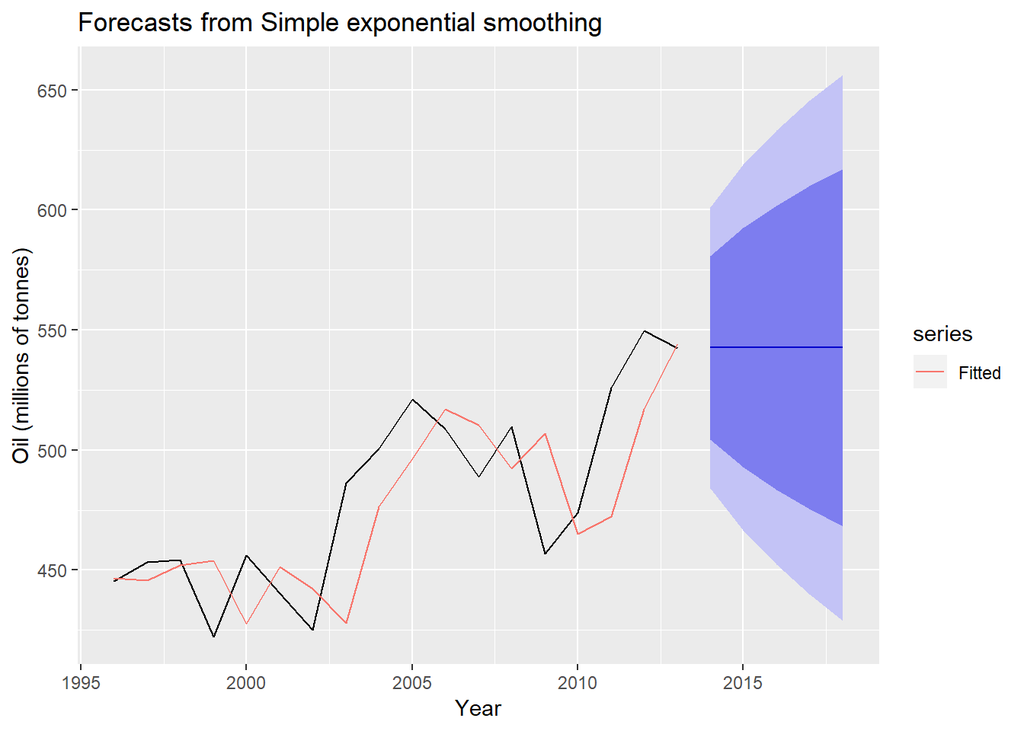

```r
autoplot(fc) +
  autolayer(fitted(fc), series ="Fitted") +
  ylab("Oil (millions of tonnes)") + xlab("Year")
```

Note that there is substantial uncertainty and so interpreting the point forecasts without accounting for the large uncertainty can be very misleading.

## Trend methods

Holt extended SES to allow forecasting of data with trend. In addition to the level equation, a trend equation is added.

$$\begin{align*}
\text{Forecast equation}&& \hat{y}_{t+h|t} &= \ell_{t} + hb_{t} \\
\text{Level equation} && \ell_{t} &= \alpha y_{t} + (1 - \alpha)(\ell_{t-1} + b_{t-1})\\
\text{Trend equation} && b_{t} &= \beta^*(\ell_{t} - \ell_{t-1}) + (1 -\beta^*)b_{t-1},
\end{align*}$$

- $l_t$ denotes an estimate of the level at time $t$
- $b_t$ denotes an estimate of the trend (slope) of the series at time t,
- $\alpha$ is the smoothing parameter for the level
- $\beta^\star$ is the smoothing parameter for the trend.
- $h$ captures the trend and is equal to the last estimated level plus h times the last estimated trend value.

Note that $l_t$ is a weighted average of observation $y_t$ and the one-step-ahead training forecast for time t, here given by $l_{t-1} + b_{t-1}$.

The trend equation shows that $b_t$ is a weighted average of the estimated trend at time t based on $l_t - l_{t-1}$ and $b_{t-1}$, the previous estimate of the trend.

```r
air <- window(ausair, start = 1990)
# estimate
fc <- holt(air, h=5)

# look at smoothing pars and trend, level states.
summary(fc)
```

```
##
## Forecast method: Holt's method
##
## Model Information:
## Holt's method
##
## Call:
##  holt(y = air, h = 5)
##
##   Smoothing parameters:
##     alpha = 0.8302
##     beta  = 1e-04
##
##   Initial states:
##     l = 15.5715
##     b = 2.1017
##
##   sigma:  2.3645
##
##      AIC     AICc      BIC
## 141.1291 143.9863 147.6083
##
## Error measures:
##                       ME     RMSE     MAE        MPE     MAPE      MASE
## Training set 0.008359331 2.182343 1.52892 -0.3244107 3.820787 0.6654839
##                     ACF1
## Training set -0.01335362
##
## Forecasts:
##      Point Forecast    Lo 80    Hi 80    Lo 95    Hi 95
## 2017       74.60130 71.57106 77.63154 69.96695 79.23566
## 2018       76.70304 72.76440 80.64169 70.67941 82.72668
## 2019       78.80478 74.13092 83.47864 71.65673 85.95284
## 2020       80.90652 75.59817 86.21487 72.78810 89.02494
## 2021       83.00826 77.13343 88.88310 74.02348 91.99305
```

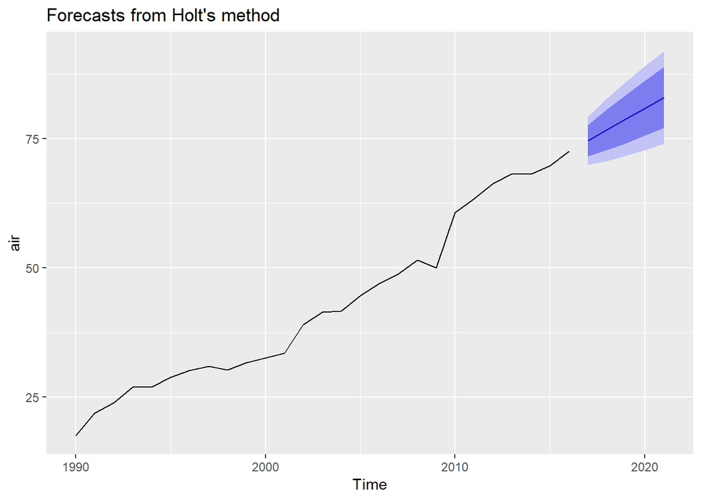

```r
autoplot(fc)
```

#### Damped trend methods

Forecast’s by Holt’s linear method display a constant trend indefinitely into the future. This leads to overforecasting, especially for longer forecast horizons.

A parameter that “dampens” the trend to a flat line some time in the future is introduced.

Holt’s method with damped trend:

$$\begin{align*}
\hat{y}_{t+h|t} &= \ell_{t} + (\phi+\phi^2 + \dots + \phi^{h})b_{t} \\
\ell_{t} &= \alpha y_{t} + (1 - \alpha)(\ell_{t-1} + \phi b_{t-1})\\
b_{t} &= \beta^*(\ell_{t} - \ell_{t-1}) + (1 -\beta^*)\phi b_{t-1}.
\end{align*}$$

- $\phi$ is the damping parameter $0 < < 1 $
- For $\phi = 1$, the method is identical to Holt’s linear method.
- For values between 0 and 1, $\phi$ dampens the trend so that it approaches a constant some time in the future.
- Usually damping is restricted to values for $\phi$ between 0.8 and a maximum of $.98$.

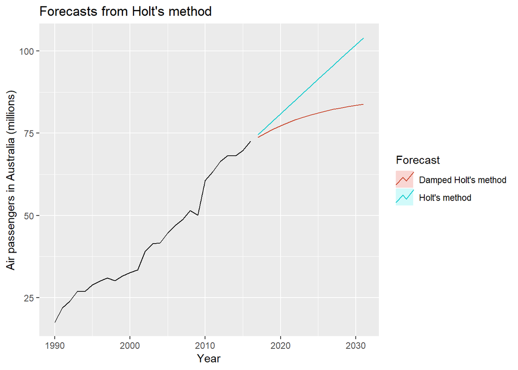

```r
# Example: holt vs. damped holt
fc <- holt(air, h=15)
fc2 <- holt(air, phi=0.9,damped=TRUE, h=15)

#
autoplot(air) +
  autolayer(fc, series="Holt's method", PI=FALSE) +
  autolayer(fc2, series="Damped Holt's method", PI=FALSE) +
  ggtitle("Forecasts from Holt's method") + xlab("Year") +
  ylab("Air passengers in Australia (millions)") +
  guides(colour=guide_legend(title="Forecast"))
```

#### Comparison non-seasonal exponential smoothing

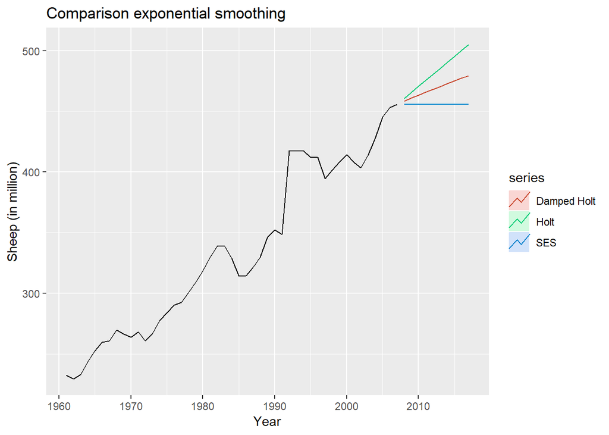

```r
# Example: Comparison SES, holt, damped holt
fc <- ses(livestock)
fc2 <- holt(livestock)
fc3 <- holt(livestock, damped=TRUE)

# plot
autoplot(livestock) +
  autolayer(fc, PI=FALSE, series="SES") +
  autolayer(fc2, PI=FALSE, series="Holt") +
  autolayer(fc3, PI=FALSE, series="Damped Holt") +
  ggtitle("Comparison exponential smoothing") +
  ylab("Sheep (in million)") +
  xlab("Year")
```

```r
# errors (time series Cross-Validation)
e1 <- tsCV(livestock, ses, h=1)
e2 <- tsCV(livestock, holt, h=1)
e3 <- tsCV(livestock, holt, damped=TRUE, h=1)

# MSE
mse <- function(error){
  mean(error^2, na.rm=TRUE)
}

MSE <- data.frame(MSE_ses=mse(e1),
                  MSE_holt=mse(e2),
                  MSE_d_holt=mse(e3))
MSE[which.min(MSE)]
```

```
##   MSE_d_holt
## 1   162.6274
```

```r
# mae
mae <- function(error){
  mean(abs(error), na.rm=TRUE)
}

MAE <- data.frame(MAE_ses=mae(e1),
                  MAE_holt=mae(e2),
                  MAE_d_holt=mae(e3))
MAE[which.min(MAE)]
```

```
##   MAE_d_holt
## 1   8.024192
```

For MAE and MSE damped holt’s method is best. Therefore, we will proceed with using the damped Holt’s method and apply it to the whole data.

```r
fc <- holt(livestock, damped=TRUE)

fc[["model"]]
```

```
## Damped Holt's method
##
## Call:
##  holt(y = livestock, damped = TRUE)
##
##   Smoothing parameters:
##     alpha = 0.9999
##     beta  = 3e-04
##     phi   = 0.9798
##
##   Initial states:
##     l = 223.35
##     b = 6.9046
##
##   sigma:  12.8435
##
##      AIC     AICc      BIC
## 427.6370 429.7370 438.7379
```

- Smoothing parameter for level $\alpha$ is close to one, showing that the level reacts strongly to each new observation.
- Smoothing parameter for the slope is essentially zero, indicating that the trend is not chanign over time.

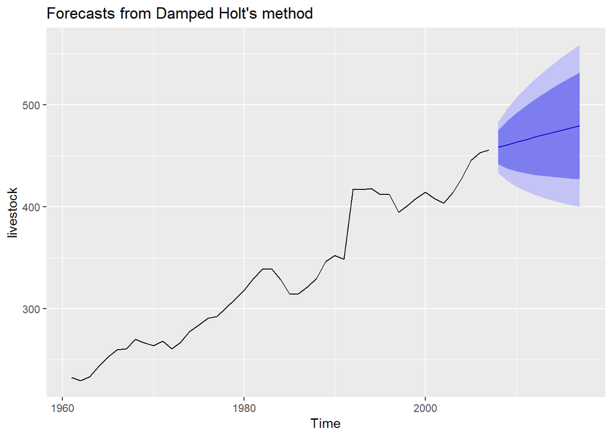

```r
autoplot(fc)
```

## Holt-Winters’ seasonal method

Extension of the Holt method to capture seasonality is called the **Holt-Winters seasonal method** consisting of the forecast equation and three smoothing equations. - one for the level $\ell_t$ - one for the trend $b_t$ - one for the seasonal component $s_t$, with corresponding smoothing parameters $\alpha, \beta^\star, \gamma$.

$m$ is used to denote the frequency of seasonality, i.e. the number of seasons in a year.

Two variations of the seasonal component:

- **Additive method**: When seasonal variations are roughly constant through the series; seasonal component is expressed in absolute terms in the scale of the observed series
- **Multiplicative method**: When the seasonal variations are changing proportional to the level of the series; Seasonal component expressed in relative terms (percentages), series is seasonally adjusted by dividing through by the seasonal component.

#### Holt-Winters’ additive method

The component form for the additive method:

$$\begin{align*}
\hat{y}_{t+h|t} &= \ell_{t} + hb_{t} + s_{t+h-m(k+1)} \\
\ell_{t} &= \alpha(y_{t} - s_{t-m}) + (1 - \alpha)(\ell_{t-1} + b_{t-1})\\
b_{t} &= \beta^*(\ell_{t} - \ell_{t-1}) + (1 - \beta^*)b_{t-1}\\
s_{t} &= \gamma (y_{t}-\ell_{t-1}-b_{t-1}) + (1-\gamma)s_{t-m},
\end{align*}$$

- k is the integer part of $(h-1)/m$ so that the estimates of the seasonal indices used for forecasting come from the final year of the sample.
- **Level equation:** Weighted average of seasonally adjusted observation $(y_t - s_{t-m})$ and non-seasonal forecast $(\ell_{t-1} + b_{t-1}$ for time t.
- **Trend equation:** Identical to Holt’s linear method.
- **Seasonal equation:** Weighted average between the current seasonal index $(y_t - \ell_{t-1} + b_{t+1})$ and seasonal index of the same season last year (i.e. m time periods ago).

#### Holt-Winter’s multiplicative method

Component form for the multiplicative method is:

$$\begin{align*}
\hat{y}_{t+h|t} &= (\ell_{t} + hb_{t}) \, s_{t+h-m(k+1)} \\
\ell_{t} &= \alpha(y_{t} / s_{t-m}) + (1 - \alpha)(\ell_{t-1} + b_{t-1})\\
b_{t} &= \beta^*(\ell_{t} - \ell_{t-1}) + (1 - \beta^*)b_{t-1}\\
s_{t} &= \gamma (y_{t}/(\ell_{t-1}+b_{t-1})) + (1-\gamma)s_{t-m}
\end{align*}$$

#### Example: Holt-Winter (additive / multiplicative)

```r
# data
aust <- window(austourists,start=2005)

# holt-winter
fit1 <- hw(aust,seasonal="additive")
fit1[["model"]]
```

```
## Holt-Winters' additive method
##
## Call:
##  hw(y = aust, seasonal = "additive")
##
##   Smoothing parameters:
##     alpha = 0.3063
##     beta  = 1e-04
##     gamma = 0.4263
##
##   Initial states:
##     l = 32.2597
##     b = 0.7014
##     s = 1.3106 -1.6935 -9.3132 9.6962
##
##   sigma:  1.9494
##
##      AIC     AICc      BIC
## 234.4171 239.7112 250.4748
```

```r
fit2 <- hw(aust,seasonal="multiplicative")
fit2[["model"]]
```

```
## Holt-Winters' multiplicative method
##
## Call:
##  hw(y = aust, seasonal = "multiplicative")
##
##   Smoothing parameters:
##     alpha = 0.4406
##     beta  = 0.0134
##     gamma = 0.0023
##
##   Initial states:
##     l = 32.4875
##     b = 0.6974
##     s = 1.0237 0.9618 0.7704 1.2442
##
##   sigma:  0.0367
##
##      AIC     AICc      BIC
## 221.1313 226.4254 237.1890
```

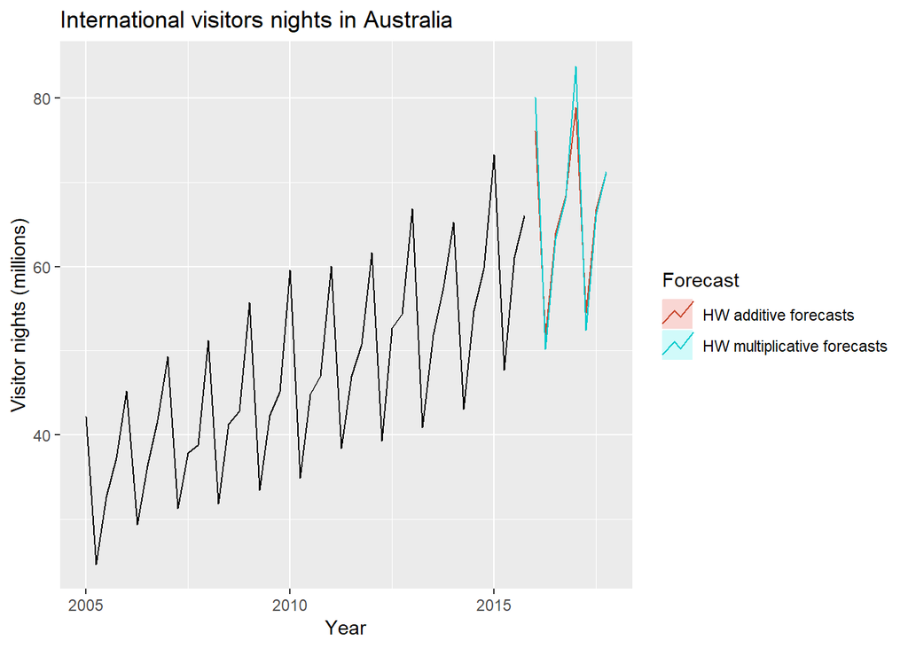

```r
# plot
autoplot(aust) +
  autolayer(fit1, series="HW additive forecasts", PI=FALSE) +
  autolayer(fit2, series="HW multiplicative forecasts",
    PI=FALSE) +
  xlab("Year") +
  ylab("Visitor nights (millions)") +
  ggtitle("International visitors nights in Australia") +
  guides(colour=guide_legend(title="Forecast"))
```

- Smoothing parameters and initial estimates for components have been estimated by minimising RMSE

#### Holt-Winters’ damped method

Damped trend is possible with additive and multiplicative seasonality. Often accurate and robsut forecasts for seasonal data with a damped trend and multiplicative seasonality, i.e. using `hw(y, damped=TRUE, seasonal="multiplicative")`:

$$\begin{align*}
\hat{y}_{t+h|t} &= \left[\ell_{t} + (\phi+\phi^2 + \dots + \phi^{h})b_{t}\right]s_{t+h-m(k+1)}. \\
\ell_{t} &= \alpha(y_{t} / s_{t-m}) + (1 - \alpha)(\ell_{t-1} + \phi b_{t-1})\\
b_{t} &= \beta^*(\ell_{t} - \ell_{t-1}) + (1 - \beta^*)\phi b_{t-1} \\
s_{t} &= \gamma \frac{y_{t}}{(\ell_{t-1} + \phi b_{t-1})} + (1 - \gamma)s_{t-m}.
\end{align*}$$

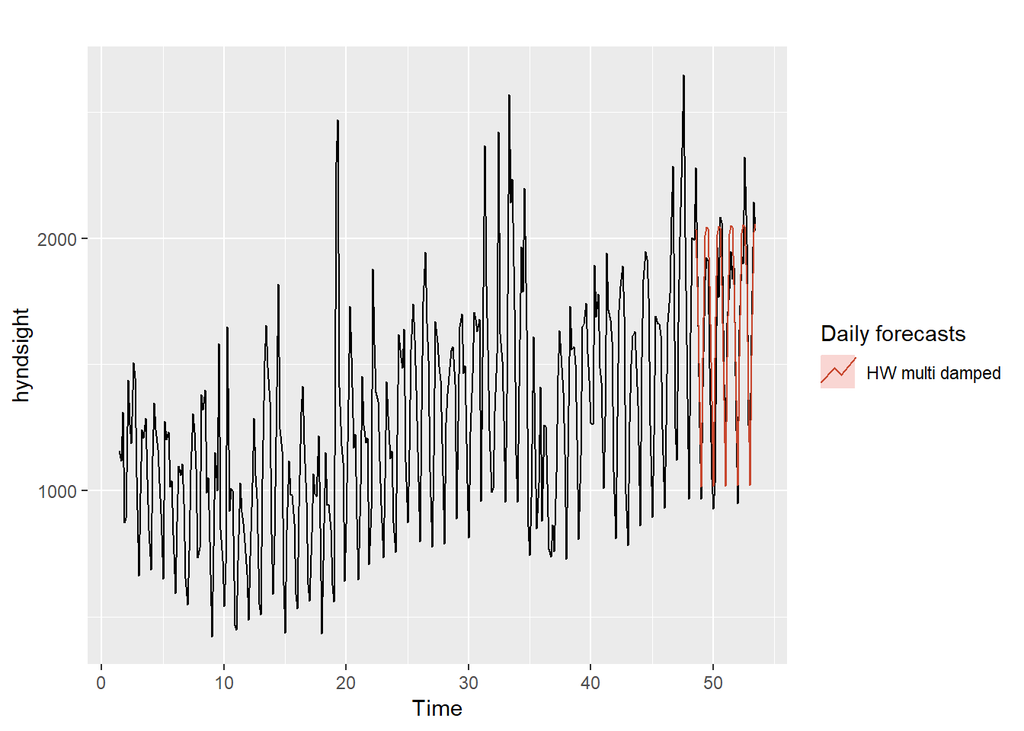

```r
### Example: HW daily data
# model
fc <- hw(subset(hyndsight,end=length(hyndsight)-35),
         damped = TRUE, seasonal="multiplicative", h=35)

# plot
autoplot(hyndsight) +
  autolayer(fc, series="HW multi damped", PI=FALSE)+
  guides(colour=guide_legend(title="Daily forecasts"))
```

## Taxonomy of exponential smoothing

Variations in the components of the trend and seasonal components yield nine exponential smoothing methods.

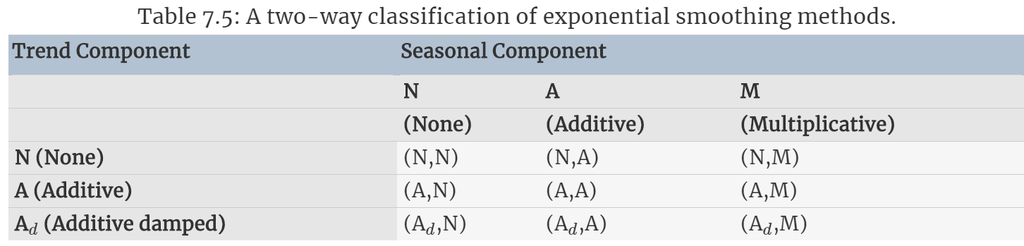

Some of these have already been introduced before:

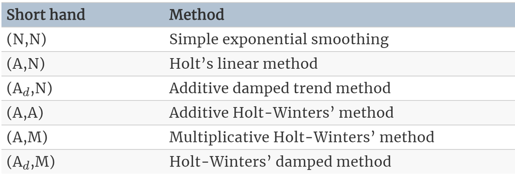

Multiplicative trend methods are not considered here as they tend to produce bad forecasts.

Overview of all the equations related to the nine exponential smoothing methods:

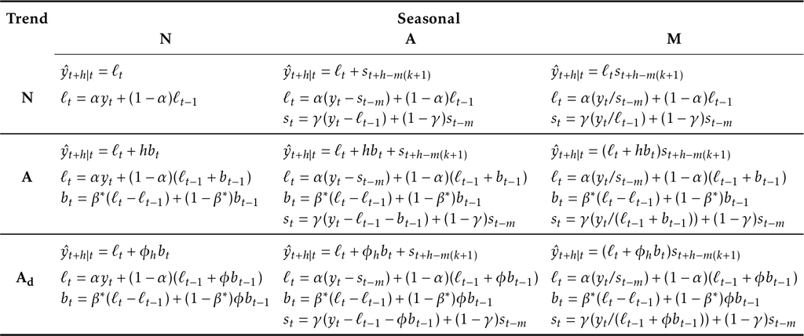

- $l_t$ denotes series level
- $b_t$ denotes slope at time t
- $s_t$ denotes the seasonal component of the series
- $m$ denotes number of seasons in a year
- $\alpha, \beta^\star, \gamma, \phi$ are smoothing parameter
- $\phi_h = \phi + \phi^2 + ... + \phi^h$
- $k$ is the integer part of $(h-1)/m$

## Innvations state space models for exponential smoothing

So far, algorithms which generate point forecasts. Now, we’ll use a statistical model which also generates prediction intervals.

- **Statistical Model:** Stochastic, data-generating process

Each model consists of:

- Measurement equation: describing observed data
- State equations: describe unobserved components or states (level, trend, seasonal) changing over time

Both equations together are referred to as **state space models**. Each method has two models: one with additive errors and one with multiplicative errors. Point forecasts produced are identical if they have the same smoothing parameter values.

To distinguish between model with additive/multiplicative errors, a third letter is added leading to the model called ETS(.,.,.) for (Error, Trend, Seasonal).

Possibilities for each component:

- $Error = {A, M}$
- $Trend = {N, A, A_d}$
- $Seasonal = {N, A, M}$

#### ETS(A,N,N): Simple exponential smoothing, additive errors

Recall the component form:

$$\begin{align*}
\text{Forecast equation} && \hat{y}_{t+1|t} & = \ell_{t}\\
\text{Smoothing equation} && \ell_{t} & = \alpha y_{t} + (1 - \alpha)\ell_{t-1},
\end{align*}$$

Re-arrange smoothing equation for the level

$$\begin{align*}
\ell_{t} &= \alpha y_{t}+\ell_{t-1}-\alpha\ell_{t-1}\\
&= \ell_{t-1}+\alpha( y_{t}-\ell_{t-1})\\
&= \ell_{t-1}+\alpha e_{t}
\end{align*}$$

where

$$e_t = y_t - l_{t-1} = y_t - \hat{y}_{t|t-1}$$

We can also rewrite this as

$$y_t = l_{t-1} + e_t$$
- Each observation is represented by last period’s level plus error - Specify probability distribution for $e_t$ to make it an innovations state space model - Additive errors: Assume residuals (one-step training errors) $e_t$ are normally distirbuted.

$$\begin{align}
y_t &= \ell_{t-1} + \varepsilon_t \\
\ell_t&=\ell_{t-1}+\alpha \varepsilon_t.
\end{align}$$

Where the first is the measurement (or observation) equation and the second the state equation. Togehter with the assumption of the error distribution we have a fully specified statistical model.

- Measurement equation shows relationship between observations and unobserved states.
- Here: $y_t$ is a linear function of the predictable part (the level $l_t$) and the unpredictable part (error $\varepsilon_t$)
- State equation shows the evolution of the state

#### ETS(M, N, N): Simple exponential smoothing with multiplicative errors

Specify models with multiplicative errors by writing the one-step-ahead training errors as relative errors:

$$\varepsilon_t = \frac{y_t-\hat{y}_{t|t-1}}{\hat{y}_{t|t-1}}$$
This can be formulated as state space model in the following way:

$$\begin{align*}
y_t&=\ell_{t-1}(1+\varepsilon_t)\\
\ell_t&=\ell_{t-1}(1+\alpha \varepsilon_t).
\end{align*}$$

#### ETS(A,A,N): Holt’s linear method with additive errors

- additive errors
- trend
- no seasonlity

One-step-ahead training errors are given by $\varepsilon_t = y_t - l_{t-1} - b_{t-1} \sim NID(0,\sigma^2)$.

Holt’s linea method is then formulated as:

$$\begin{align*}
y_t&=\ell_{t-1}+b_{t-1}+\varepsilon_t\\
\ell_t&=\ell_{t-1}+b_{t-1}+\alpha \varepsilon_t\\
b_t&=b_{t-1}+\beta \varepsilon_t,
\end{align*}$$
where, for simplicity, we have $\beta = \alpha \beta^\star$

#### ETS(M,A,N): Holt’s linear methods with multiplicative errors

One-step-ahead training errors as relative errors:

$$\varepsilon_t=\frac{y_t-(\ell_{t-1}+b_{t-1})}{(\ell_{t-1}+b_{t-1})}$$

Innovations state space model:

$$\begin{align*}
y_t&=(\ell_{t-1}+b_{t-1})(1+\varepsilon_t)\\
\ell_t&=(\ell_{t-1}+b_{t-1})(1+\alpha \varepsilon_t)\\
b_t&=b_{t-1}+\beta(\ell_{t-1}+b_{t-1}) \varepsilon_t
\end{align*}$$

where again $\beta = \alpha \beta$ and $\varepsilon \sim NID(0,\sigma^2)$

### Other ETS models

All statee equations for each of the models in the ETS framework.

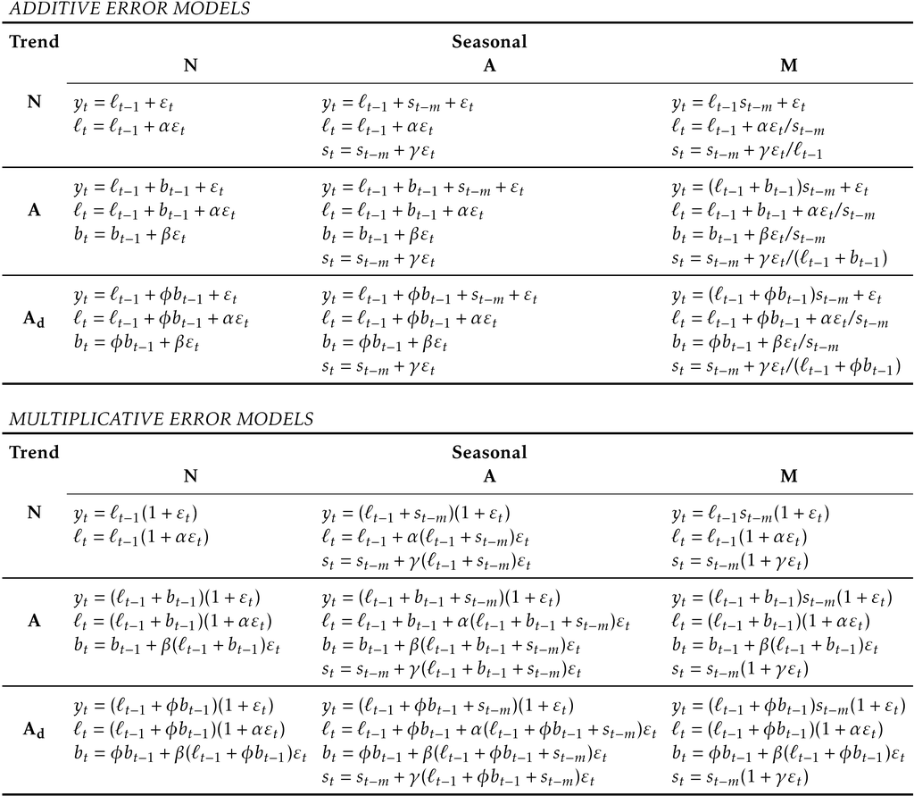

## Estimation and model selection

#### Estimating ETS models

Two appraoches:

- Minimising sum of squared errors
- Alternative: Maximise “likelihood”

Same results for additive error model but different results for multiplicative error models. Estimate smoothing parameters

- $\alpha, \beta, \gamma, \phi$

and initial states

- $\ell_0, b_0, s_0, s_{-1}, ..., s_{-m+1}$

by MLE.

- Possible values are restricted

## Model selection

In the ETS framework information criteria can be used for model selection. For ETS models these are defined as

$$\text{AIC} = -2\log(L) + 2k$$
- L is likelihood of the model and $k$ the total number of parameters and initial states

$$\text{AIC}_{\text{c}} = \text{AIC} + \frac{k(k+1)}{T-k-1},$$
$$\text{BIC} = \text{AIC} + k[\log(T)-2].$$

Following models can cause numerical difficulties due to division by values potentially close to zero in the state equations:

- ETS(A,N,M)
- ETS(A,A,M)
- ETS(A,A$_d$,M)

In general, we do not consider these particular combinations when selecting a model.

Models with multiplicative errors are useful when data are strictly positive, but not numerically stable when the data contain zeros or negative values.

Therefore, multiplicative error models will not be considered if the time series is not strictly positive. Only the six fully additive models will be applied.

#### The `ets()` function in R

Unlike previous methods (i.e. `ses()`, `holt()`, `hw()`), the `ets()` function yields a model with estimated parameters and information about the fitted model. AICc is used to select an appropriate model, although other information criteria can be selected.

- For more information use `?ets()`

#### Working with `ets()` objects

The function returns an object of class `ets`. Important functions:

- `coef()`: returns fitted parameters
- `accuracy()`: returns accuracy measures computed on training data
- `summary()` prints summary information
- `autoplot()`,`plot()`: time plots of the components
- `residuals()`: returns residuals from the estimated model
- `fitted()`: returns one-step forecasts for the training data.
- `simulate()`: will simulate future sample paths from the fitted model.
- `forecast()`: computes point forecasts and prediction intervals

#### Example: International tourist visitor nights in Australia

```r
aust <- window(austourists, start = 2005)
fit <- ets(aust)

# see model fit
summary(fit)
```

```
## ETS(M,A,M)
##
## Call:
##  ets(y = aust)
##
##   Smoothing parameters:
##     alpha = 0.1908
##     beta  = 0.0392
##     gamma = 2e-04
##
##   Initial states:
##     l = 32.3679
##     b = 0.9281
##     s = 1.0218 0.9628 0.7683 1.2471
##
##   sigma:  0.0383
##
##      AIC     AICc      BIC
## 224.8628 230.1569 240.9205
##
## Training set error measures:
##                      ME     RMSE     MAE        MPE     MAPE     MASE
## Training set 0.04836907 1.670893 1.24954 -0.1845609 2.692849 0.409454
##                   ACF1
## Training set 0.2005962
```

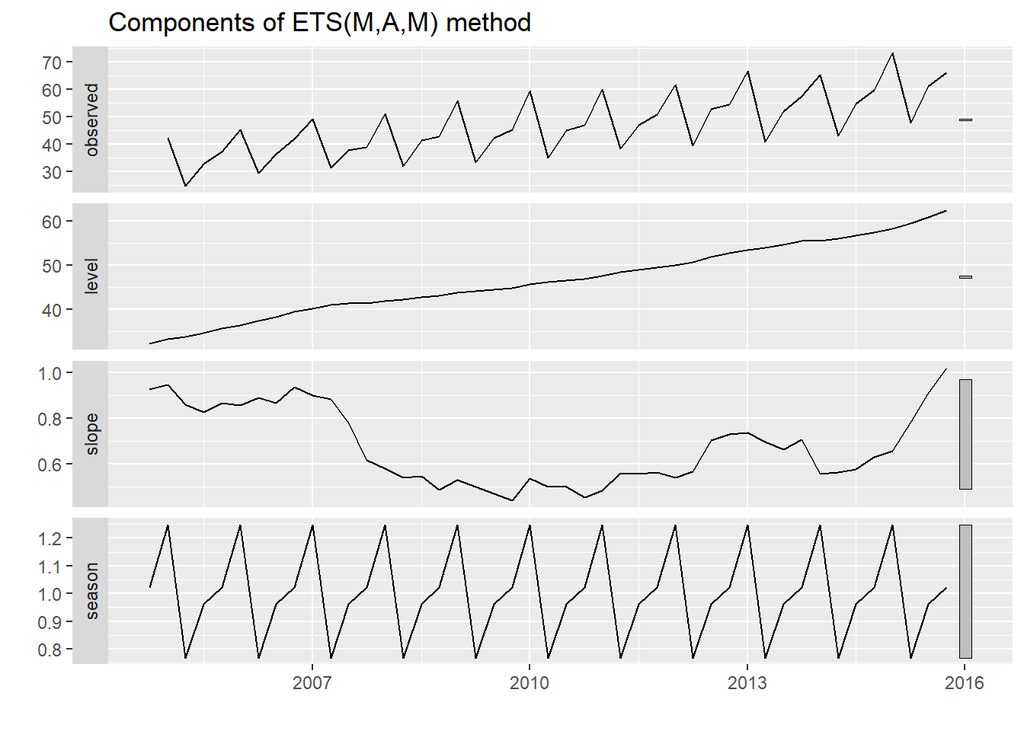

```r
# plot
autoplot(fit)
```

The model selected is ETS(M,A,M):

$$\begin{align*}
y_{t} &= (\ell_{t-1} + b_{t-1})s_{t-m}(1 + \varepsilon_t)\\
\ell_t &= (\ell_{t-1} + b_{t-1})(1 + \alpha \varepsilon_t)\\
b_t &=b_{t-1} + \beta(\ell_{t-1} + b_{t-1})\varepsilon_t\\
s_t &= s_{t-m}(1+ \gamma \varepsilon_t).
\end{align*}$$

With multiplicative errors, the residuals are not equivalent to the one-step training errors.

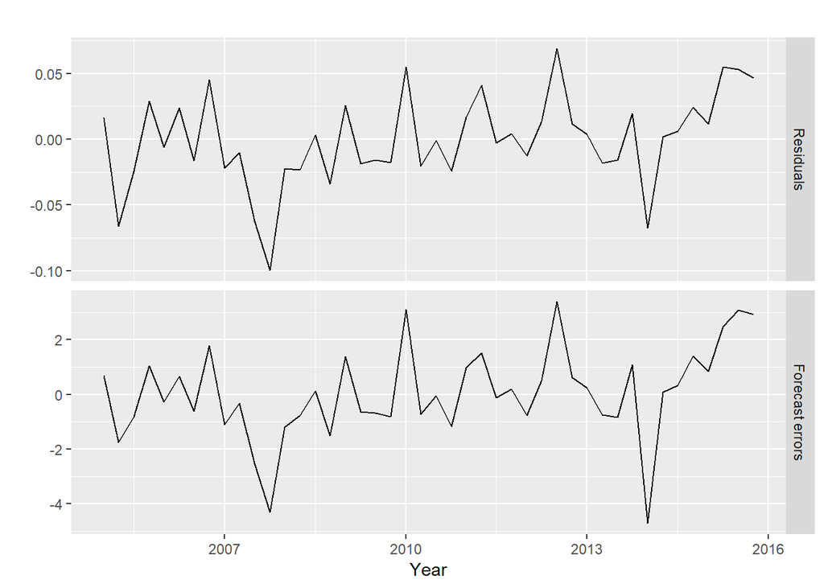

```r
cbind("Residuals"=residuals(fit),
      "Forecast errors"=residuals(fit, type="response")) %>%
  autoplot(facet=TRUE) + xlab("Year") + ylab("")
```

## Forecasting with ETS models

ETS point forecasts are equal to the medians of the forecast distributions. For models with only additive components, the forecast distributions are normal, hence medians and means are equal.

For ETS models with multiplicative errors or multiplicative seasonality, the point forecasts will not be equal to the means of the forecast distributions.

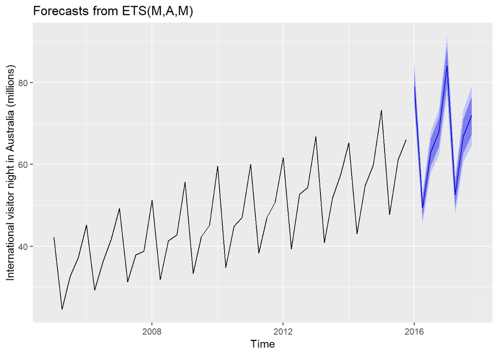

```r
fit %>%
  forecast(h=8) %>%
  autoplot() +
  ylab("International visitor night in Australia (millions)")
```

#### Prediction intervals

- Advantage: Prediction intervals (PI) can be generated
- PI will differ between models with additive and multiplicative methods.

$$\hat{y}_{T+h|T} \pm c \sigma_h$$

where c depends on the coverage probability, and $\sigma_h^2$ is the forecast variance. The following table give the formulas for the additive ETS models (which are the simplest).

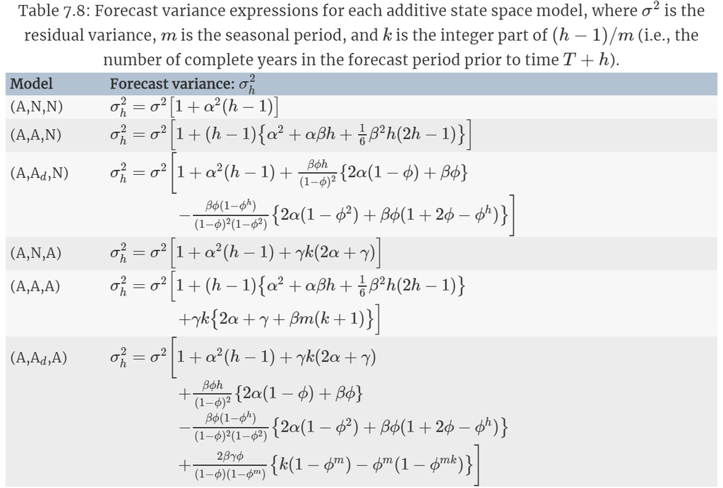

#### Using `forecast()`

Explanations of some new arguments:

- `simulate()`: If `simulate=TRUE`, predicion intervals are produced by simultion rather than algebraic formulas. Simlation will also be used where there are no algebraic formulas available for the particular model.
- If `bootstrap=TRUE` and `simulate=TRUE`, then the simulated prediction intervals use re-sampled errors rather than normally distributed errors.
- `npaths`: The number of sample paths used in computing simulated prediction intervals.
- `biasadj`: If `lambda` is not `NULL`, the back-transformed forecasts (and PI) are bias-adjusted.

## Exercises

#### Ex.1

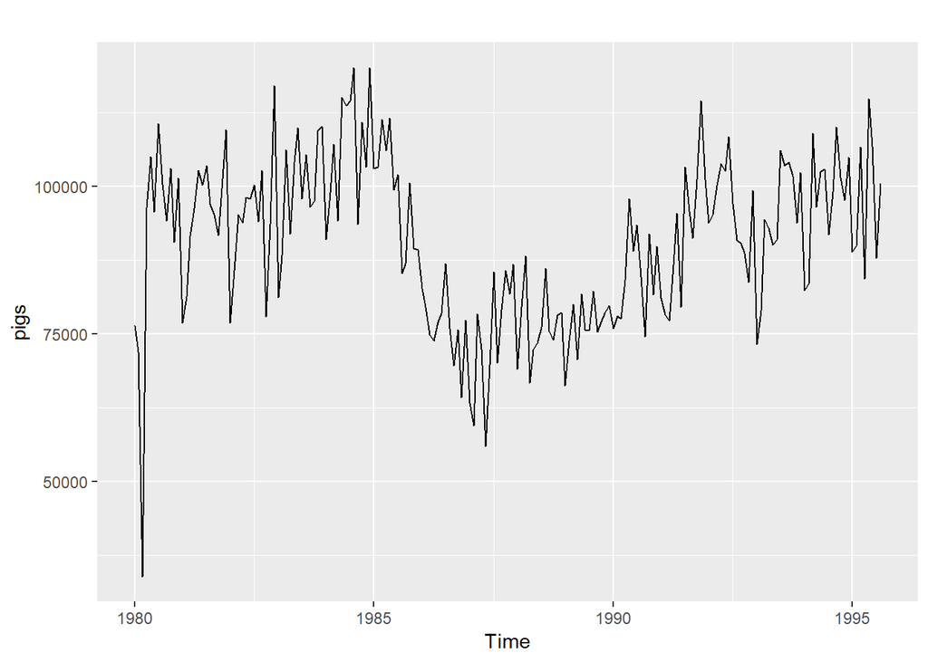

```r
autoplot(pigs)
```

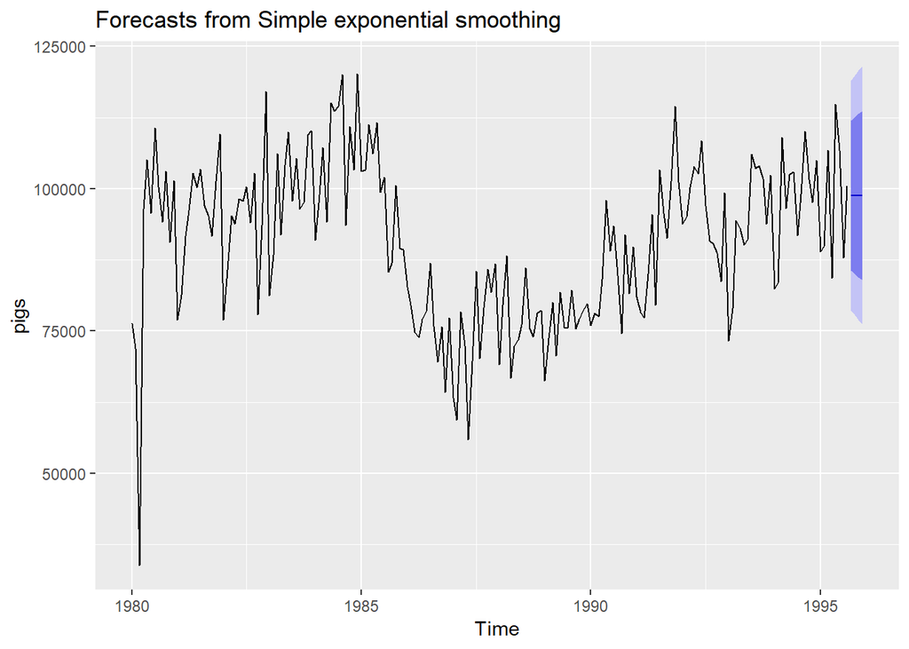

```r
fit <- ses(pigs, h=4)
autoplot(fit)
```

```r
summary(fit)
```

```
##
## Forecast method: Simple exponential smoothing
##
## Model Information:
## Simple exponential smoothing
##
## Call:
##  ses(y = pigs, h = 4)
##
##   Smoothing parameters:
##     alpha = 0.2971
##
##   Initial states:
##     l = 77260.0561
##
##   sigma:  10308.58
##
##      AIC     AICc      BIC
## 4462.955 4463.086 4472.665
##
## Error measures:
##                    ME    RMSE      MAE       MPE     MAPE      MASE
## Training set 385.8721 10253.6 7961.383 -0.922652 9.274016 0.7966249
##                    ACF1
## Training set 0.01282239
##
## Forecasts:
##          Point Forecast    Lo 80    Hi 80    Lo 95    Hi 95
## Sep 1995       98816.41 85605.43 112027.4 78611.97 119020.8
## Oct 1995       98816.41 85034.52 112598.3 77738.83 119894.0
## Nov 1995       98816.41 84486.34 113146.5 76900.46 120732.4
## Dec 1995       98816.41 83958.37 113674.4 76092.99 121539.8
```

```r
# 95% PI
```

#### 2.

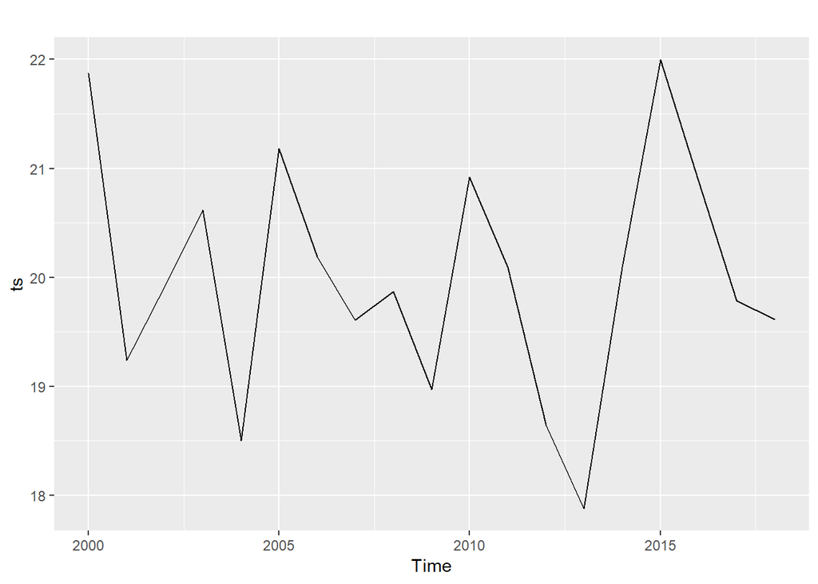

```r
# from fit
alpha <- 0.2971
ell <- 77260
sigma <- 10308

# test series
ts <- ts(rnorm(19, 20, 1),start = c(2000,1))
autoplot(ts)
```

```r
tm_ses <- function(y, alpha, level){
  last <- y[length(y)]
  alpha*last + (1-alpha)*level
  }

tm_ses(ts, 0.5, 20)
```

```
## [1] 19.80581
```

```r
tm_ses(pigs, alpha, ell)
```

```
## [1] 84166.39
```

#### 5.

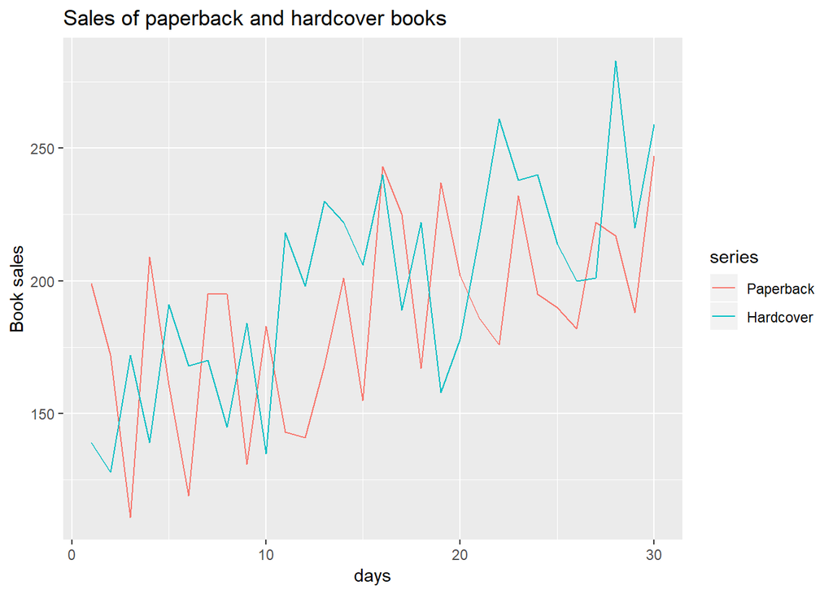

```r
autoplot(books) +
  ggtitle("Sales of paperback and hardcover books") +
  ylab("Book sales") +
  xlab("days")
```

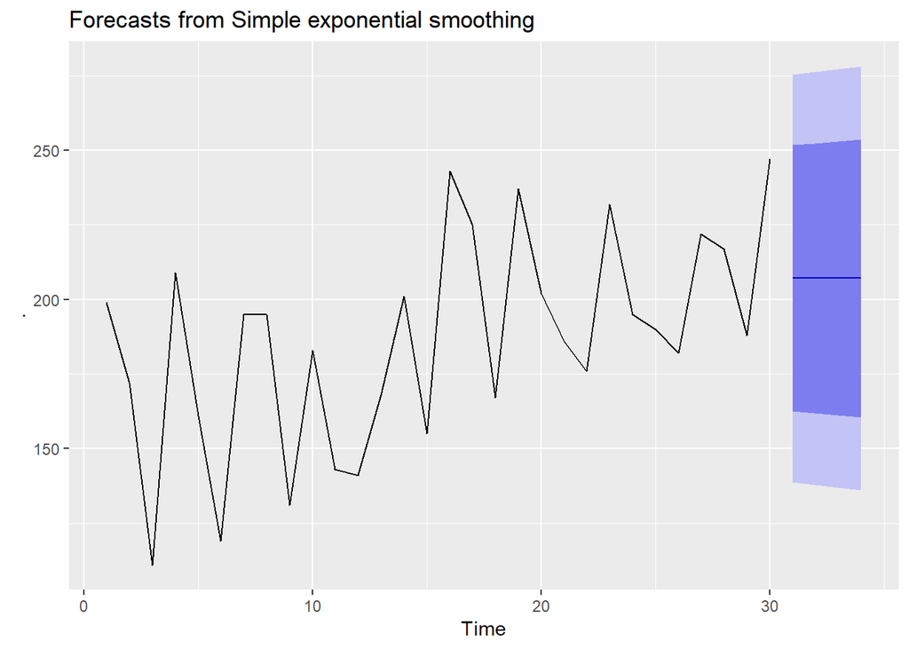

```r
# Paperback
books[,"Paperback"] %>%
  ses(h=4) %>%
  autoplot()
```

```r
fit_paper <- ses(books[,"Paperback"])
accuracy(fit_paper)
```

```
##                    ME     RMSE     MAE       MPE     MAPE      MASE
## Training set 7.175981 33.63769 27.8431 0.4736071 15.57784 0.7021303
##                    ACF1
## Training set -0.2117522
```

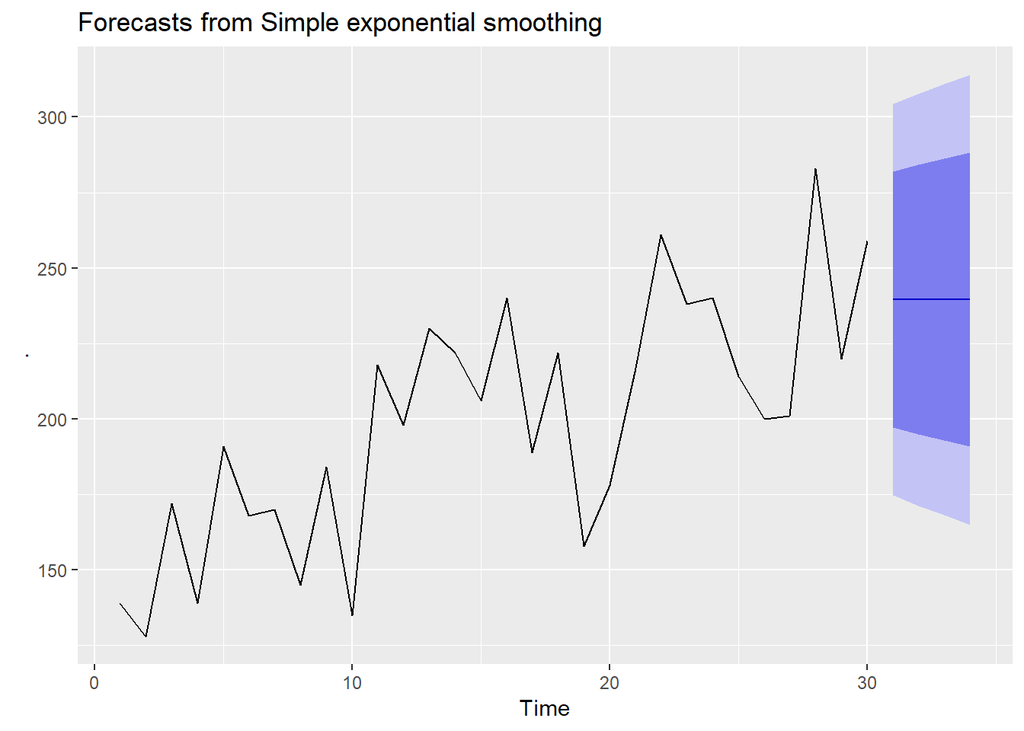

```r
# Hardcover
books[,"Hardcover"] %>%
  ses(h=4) %>%
  autoplot()
```

```r
fit_hard <- ses(books[,"Hardcover"])
accuracy(fit_hard)
```

```
##                    ME     RMSE      MAE      MPE     MAPE      MASE
## Training set 9.166735 31.93101 26.77319 2.636189 13.39487 0.7987887
##                    ACF1
## Training set -0.1417763
```

#### Exercise 6

```r
# fit holt method
fit_paper <- holt(books[,"Paperback"], h=4)
fit_hard <- holt(books[, "Hardcover"], h=4)

rbind(accuracy(fit_paper), accuracy(fit_hard))
```

```
##                      ME     RMSE      MAE       MPE     MAPE      MASE
## Training set -3.7171783 31.13692 26.18083 -5.508526 15.58354 0.6602122
## Training set -0.1357882 27.19358 23.15557 -2.114792 12.16260 0.6908555
##                     ACF1
## Training set -0.17507925
## Training set -0.03245186
```

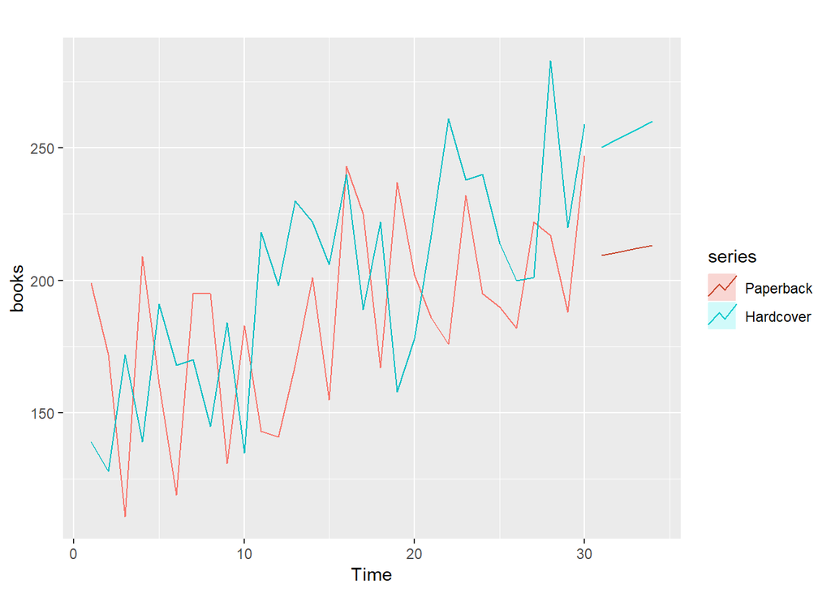

```r
# plot
autoplot(books, series="book") +
  autolayer(fit_hard, PI=F, series="Hardcover") +
  autolayer(fit_paper, PI=F, series="Paperback")
```

#### Exercise 7

Use various options of the `holt()` method.

- default
- damped trend
- Box-Cox transformation

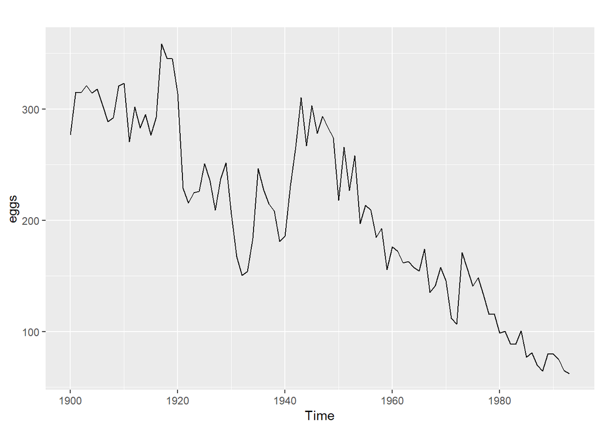

```r
autoplot(eggs)
```

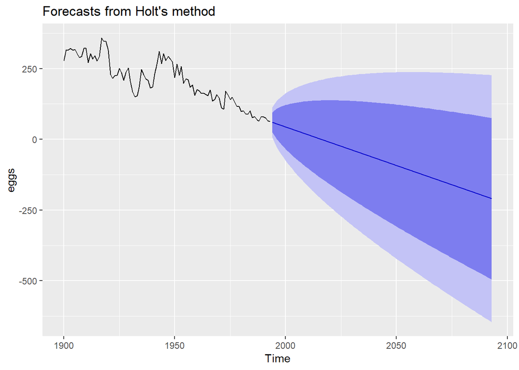

```r
fit_h1 <- holt(eggs, h=100)
autoplot(fit_h1)
```

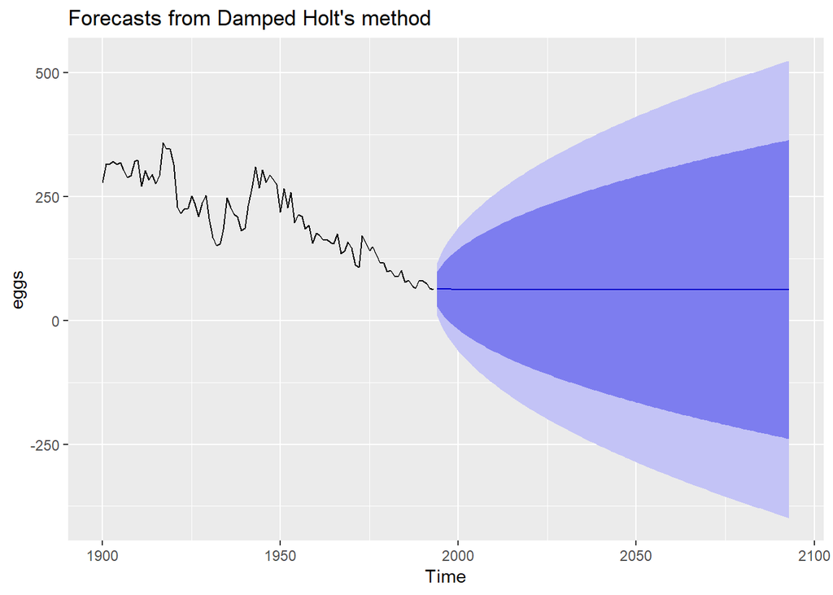

```r
fit_h2 <- holt(eggs, h=100, damped = TRUE)
autoplot(fit_h2)
```

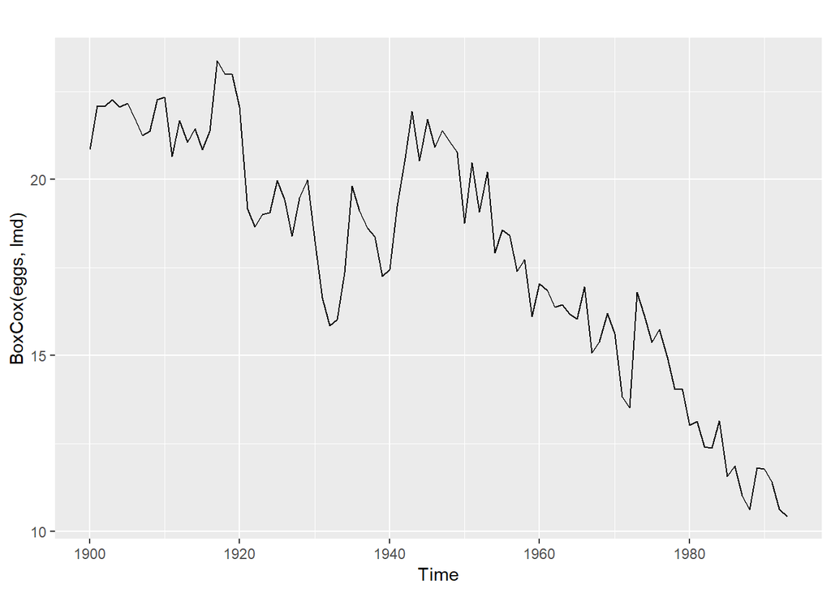

```r
lmd <- BoxCox.lambda(eggs)
autoplot(BoxCox(eggs, lmd))
```

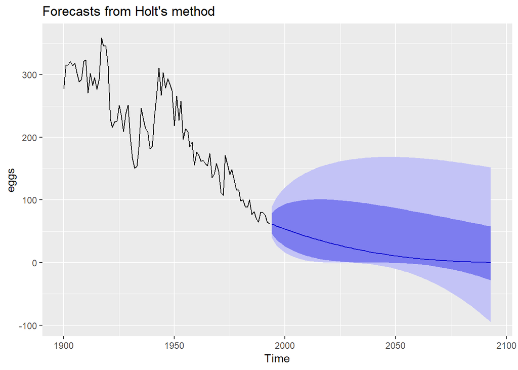

```r
fit_h3 <- holt(eggs, h = 100, lambda = lmd)
autoplot(fit_h3)
```

#### Exercise 8

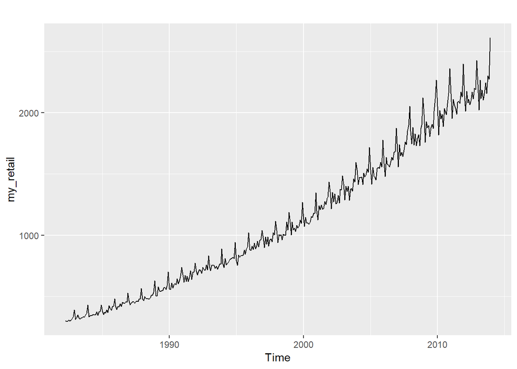

```r
retail <- readxl::read_excel("../data/retail.xlsx", skip=1)

my_retail <- ts(retail[,"A3349335T"],
                frequency=12,
                start=c(1982,4))

autoplot(my_retail)
```

```r
# Holt-Winter
fit_hw <- hw(my_retail, h=8)
acc1 <- accuracy(fit_hw)[,c("RMSE","MAE", "MAPE","MASE")]

fit_hw_d <- hw(my_retail, h=8, damped = TRUE)
acc2 <- accuracy(fit_hw_d)[,c("RMSE","MAE", "MAPE","MASE")]

data.frame(Accuracy_HW = acc1, Accuracy_HW_d=acc2)
```

```
##      Accuracy_HW Accuracy_HW_d
## RMSE   28.609822    29.5895856
## MAE    21.350138    21.9877097
## MAPE    2.302883     2.3681747
## MASE    0.343045     0.3532893
```

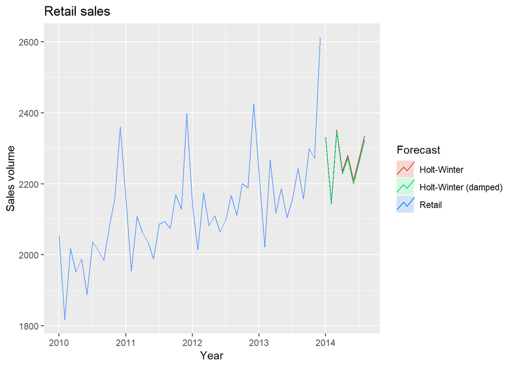

```r
autoplot(window(my_retail, start=c(2010,1)), series="Retail") +
  autolayer(fit_hw, series="Holt-Winter", PI=F) +
  autolayer(fit_hw_d, series="Holt-Winter (damped)", PI=F) +
  ggtitle("Retail sales") +
  xlab("Year") +
  ylab("Sales volume") +
  guides(colour=guide_legend(title="Forecast"))
```

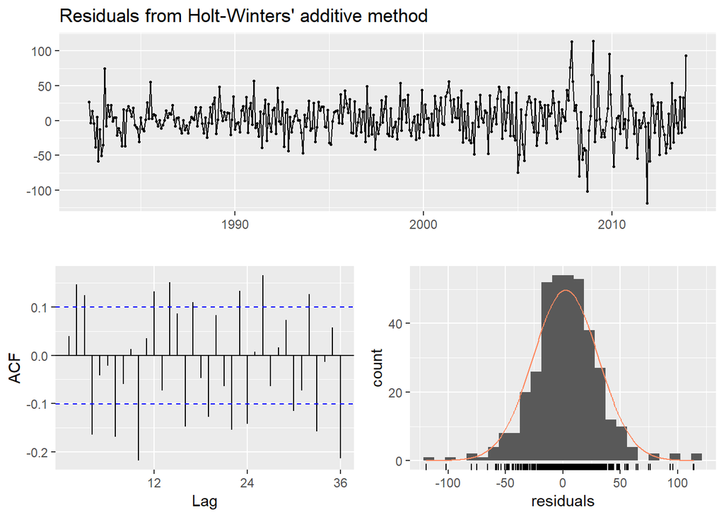

```
##
##  Ljung-Box test
##
## data:  Residuals from Holt-Winters' additive method
## Q* = 130.17, df = 8, p-value < 2.2e-16
##
## Model df: 16.   Total lags used: 24
```

```r
checkresiduals(fit_hw)
```